# Лабораторная работа №5-F. ЗАХВАТ КОНТРОЛЛЕРА ДОМЕНА 2

Кибербезопасность предприятия

Боровиков Даниил

Хрусталев Влад

Гисматуллин Артём

Чесноков Артёмий

Коннова Татьяна

Нефедова Наталья

Уткина Алина

Бансимба Клодели

Российский университет дружбы народов, Москва, Россия

## Цель работы

- Получить доступ к контроллеру домена в сети `195.239.174.0/24`
- Создать доменного пользователя `hacker`
- Добавить его в локальную группу `Administrators`
- Получить флаг в поле `Comment` пользователя `hacker`

## Основные этапы атаки

1. **Разведка сети** – обнаружение почтового сервера Exchange (`195.239.174.1`)
2. **Эксплуатация ProxyLogon** – получение сессии через CVE-2021-26855
3. **Внутренняя разведка** – обнаружение AD (`10.10.10.20`) и CS (`10.10.10.40`)
4. **Обнаружение уязвимости ESC8** в AD CS
5. **NTLM Relay + PetitPotam** – получение сертификата контроллера домена
6. **Получение TGT-билета** и дамп хешей администратора
7. **Захват контроллера** через psexec с NTLM-хешем
8. **Создание пользователя `hacker`** и получение флага

## Ключевые уязвимости и инструменты

**Уязвимости:** - CVE-2021-26855 (ProxyLogon) – начальный доступ - ESC8 (AD CS) – эскалация привилегий через сертификаты - PetitPotam – принуждение к аутентификации

**Инструменты:** - Metasploit (ProxyLogon, psexec, SOCKS proxy) - Impacket (ntlmrelayx, secretsdump, smbexec) - Certipy, PetitPotam, responder

## Результат

- Получен полный доступ к контроллеру домена `ad.ampire.corp`
- Создан пользователь `hacker`, добавлен в `Administrators`
- Получен флаг: **35269** (в поле `Comment` пользователя `hacker`)

## Отчет

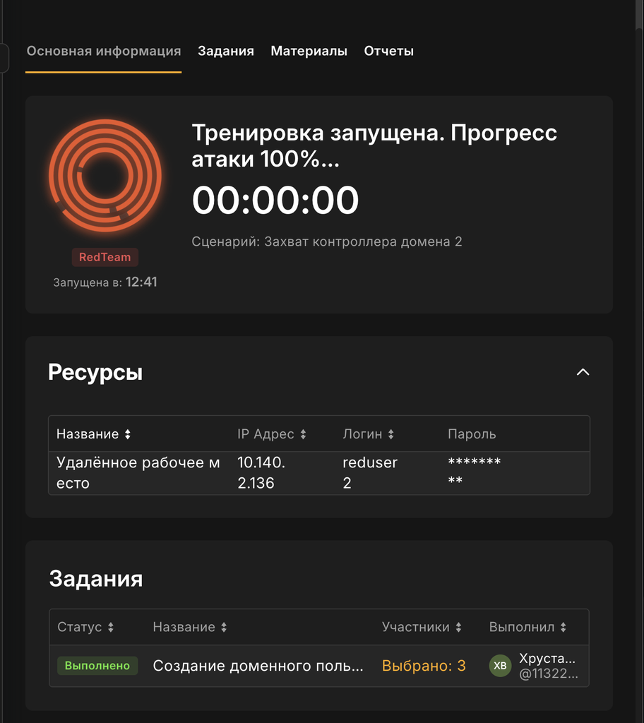

Выполнение работы

## Выводы

Работа продемонстрировала цепочку атак от внешнего периметра до полного контроля над доменом:

1. Важность своевременного обновления Exchange Server
2. Риски некорректной настройки AD Certificate Services
3. Опасность NTLM Relay-атак и принудительной аутентификации
4. Необходимость мониторинга аномальной активности в домене